# Watterson - PhD Dissertation

# Set-Up Environment

0.5 Install R Packages

```r
install.packages("sjPlot","multcomp","olsrr","dplyr","readr","ggplot2","ggthemes","likert","intsvy","tidyselect","Hmisc","knitr")
```

```
Error in install.packages : Updating loaded packages
```

1. Load in R Packages

```r
library(sjPlot)
library(multcomp)
library(olsrr)
library(dplyr)
library(readr)
library(ggplot2)
library(ggthemes)
library(likert)
library(intsvy)
library(tidyselect)
library(Hmisc)
library(knitr)
```

# Import Data Set from Redcap

1. Read in Data Set
2. Set headers and descriptions (i.e., questions)
3. Assign numerical values to categorical response variables
4. Added new variables with factor labels

```r
#Read Data
data=read.csv('DATA.csv')

#Setting Labels
label(data$record_id)="Record ID"
label(data$setting)="Which of the following describes your practice setting?"
label(data$years_pharmacy)="How many years have you worked at this pharmacy (including as a technician or intern)?"
label(data$years_pharmacist)="How many years have you worked at this pharmacy as a pharmacist?"
label(data$prescriptions)="What is the average number of prescriptions this pharmacy fills on a typical weekday?"
label(data$full_time_rph)="On a typical weekday, how many full time pharmacists work in this pharmacy?"
label(data$part_time_rph)="On a typical weekday, how many part time pharmacists work in this pharmacy?"
label(data$float_rph)="On a typical weekday, how many float/relief pharmacists work in this pharmacy?"
label(data$full_time_staff)="On a typical weekday, how many full time technicians, clerks, and student interns work in this pharmacy?"
label(data$part_time_staff)="On a typical weekday, how many part time technicians, clerks, and student interns work in this pharmacy?"
label(data$float_staff)="On a typical weekday, how many float/relief technicians, clerks, and student interns work in this pharmacy?"
label(data$age)="How old did you turn on your last birthday?"
label(data$hours_sleep)="How many hours of sleep do you get most nights?"
label(data$caffeine)="How many servings of caffeine do you consume most days?"
label(data$race___1)="Which of the following best describes your race or ethnicity? Please check all that apply. (choice=American Indian or Alaska Native)"
label(data$race___2)="Which of the following best describes your race or ethnicity? Please check all that apply. (choice=Asian or Pacific Islander)"
label(data$race___3)="Which of the following best describes your race or ethnicity? Please check all that apply. (choice=Black, not of Hispanic origin)"
label(data$race___4)="Which of the following best describes your race or ethnicity? Please check all that apply. (choice=Hispanic)"
label(data$race___5)="Which of the following best describes your race or ethnicity? Please check all that apply. (choice=White, not of Hispanic origin)"
label(data$gender)="What is your gender?"
label(data$marital_status)="What is your marital status?"
label(data$adults_house)="How many individuals over the age of 18 live in your household (including yourself)?"
label(data$minors_house)="How many individuals under the age of 18 live in your household?"
label(data$shifts)="Using the calendar below, please mark with an X each day that you worked during the last two weeks."
label(data$days_worked)="Thinking about the last two weeks... how many days did you work?"
label(data$hours_worked)="Thinking about the last two weeks... how many hours did you work most days?"
label(data$lunch)="During the last two weeks, did you ever take a scheduled break during the workday? A scheduled break includes any paid or un-paid periods of time where you were not working, such as a lunch break."
label(data$energy)="Feel that your energy decreased over the course of the day?"
label(data$tired)="Feel more tired later in the day than you did at the beginning of the day?"
label(data$pain)="Feel pain or discomfort anywhere in your body?"
label(data$thinking)="Have trouble thinking clearly at work, even for a short time?"
label(data$forget)="Have times where you forgot whether or not you had completed a task?"
label(data$spent_longer)="Have times where you spent longer completing a task later in the day than you would at the beginning of the day?"
label(data$keep_up)="Have times where you felt that you could not keep up with your work?"
label(data$impatient)="Have times where you felt more impatient later in the day than you did at the beginning of the day?"
label(data$performing)="Have times where you felt that you were not performing at your best?"
label(data$short_cuts)="Find it necessary to take short-cuts when providing patient care?"
label(data$above_beyond)="Have times where you felt that you were not able to go above and beyond standard patient care?"
label(data$fatigue_general)="Have times where you felt generally fatigued?"
label(data$tired_general)="Consider the last two weeks. At the end of most workdays, how tired did you feel?"
label(data$fatigue_safety)="In general, how much do you think pharmacist fatigue affects patient safety?"
label(data$fatigue_concern)="In general, how concerned are you about fatigue in pharmacists?"
label(data$lunch_fatigue)="How much do you think scheduled breaks during the workday would help pharmacists to cope with fatigue?"
label(data$readiband)="Readiband CSV File"
label(data$readiscore_average)="Average Readiscore"
label(data$percent_high)="Percentage of Time Spent at High Effectiveness"
label(data$reduced_effectiveness)="Percentage of Time Spent at Reduced Effectiveness"
label(data$low_effectiveness)="Percentage of Time Spent at Low Effectiveness"
label(data$sleep_quantity)="Sleep Quantity"
label(data$sleep_quality)="Sleep Quality"
label(data$awakenings_hour)="Awakenings Per Hour"
label(data$wake_after_onset)="Wake After Sleep Onset"
label(data$sleep_onset)="Sleep Onset"
label(data$wake_time)="Wake Time"
label(data$i_feel_emotionally_drained)="I feel emotionally drained from my work"
label(data$i_feel_used_up_at_the_end)="I feel used up at the end of the workday"
label(data$i_feel_fatigued_when_i_get)="I feel fatigued when I get up in the morning and have to face another day on the job"
label(data$i_can_easily_understand_ho)="I can easily understand how my patients feel about things"
label(data$i_feel_i_treat_some_patien)="I feel I treat some patients as if they were impersonal objects"
label(data$working_with_people_all_da)="Working with people all day is really a strain for me"
label(data$i_deal_very_effectively_wi)="I deal very effectively with the problems of my patients"
label(data$i_feel_burned_out_from_my)="I feel burned out from my work"
label(data$i_feel_i_m_positively_infl)="I feel Im positively influencing the other peoples lives through my work"
label(data$i_ve_become_more_callous_t)="Ive become more callous toward people since I took this job"
label(data$i_worry_that_this_job_is_h)="I worry that this job is hardening me emotionally"
label(data$i_feel_very_energetic)="I feel very energetic"
label(data$i_feel_frustrated_by_my_jo)="I feel frustrated by my job"
label(data$i_feel_i_m_working_too_har)="I feel Im working too hard on my job"
label(data$i_don_t_really_care_what_h)="I dont really care what happens to some patients"
label(data$working_with_people_direct)="Working with people directly puts too much stress on me"
label(data$i_can_easily_create_a_rela)="I can easily create a relaxed atmosphere with my patients"
label(data$i_feel_exhilarated_after_w)="I feel exhilarated after working closely with my patients"
label(data$i_have_accomplished_many_w)="I have accomplished many worthwhile things in this job"
label(data$i_feel_like_i_m_at_the_end)="I feel like Im at the end of my rope"
label(data$in_my_work_i_deal_with_emo)="In my work, I deal with emotional problems very calmly"
label(data$i_feel_patients_blame_me_f)="I feel patients blame me for their problems"
label(data$ee_total)="EE Total Score"
label(data$ee_average)="EE Average Score"
label(data$dp_total)="DP Total Score"
label(data$dp_average)="DP Average Score"
label(data$pa_total)="PA Total Score"
label(data$pa_average)="PA Average Score"
```

```r
#Setting Units
#Setting Factors(create new variables for factors)
data$setting.factor = factor(data$setting,levels=c("1","2","3","4","5"))
data$race___1.factor = factor(data$race___1,levels=c("0","1"))
data$race___2.factor = factor(data$race___2,levels=c("0","1"))
data$race___3.factor = factor(data$race___3,levels=c("0","1"))
data$race___4.factor = factor(data$race___4,levels=c("0","1"))
data$race___5.factor = factor(data$race___5,levels=c("0","1"))
data$gender.factor = factor(data$gender,levels=c("1","2","3"))
data$marital_status.factor = factor(data$marital_status,levels=c("1","2","3","4","5"))
data$lunch.factor = factor(data$lunch,levels=c("1","0"))
data$energy.factor = factor(data$energy,levels=c("1","2","3","4","5"))
data$tired.factor = factor(data$tired,levels=c("1","2","3","4","5"))
data$pain.factor = factor(data$pain,levels=c("1","2","3","4","5"))
data$thinking.factor = factor(data$thinking,levels=c("1","2","3","4","5"))
data$forget.factor = factor(data$forget,levels=c("1","2","3","4","5"))
data$spent_longer.factor = factor(data$spent_longer,levels=c("1","2","3","4","5"))
data$keep_up.factor = factor(data$keep_up,levels=c("1","2","3","4","5"))
data$impatient.factor = factor(data$impatient,levels=c("1","2","3","4","5"))
data$performing.factor = factor(data$performing,levels=c("1","2","3","4","5"))
data$short_cuts.factor = factor(data$short_cuts,levels=c("1","2","3","4","5"))
data$above_beyond.factor = factor(data$above_beyond,levels=c("1","2","3","4","5"))
data$fatigue_general.factor = factor(data$fatigue_general,levels=c("1","2","3","4","5"))
data$tired_general.factor = factor(data$tired_general,levels=c("1","2","3","4","5"))
data$fatigue_safety.factor = factor(data$fatigue_safety,levels=c("1","2","3","4","5"))
data$fatigue_concern.factor = factor(data$fatigue_concern,levels=c("1","2","3","4","5"))
data$lunch_fatigue.factor = factor(data$lunch_fatigue,levels=c("1","2","3","4","5"))
data$i_feel_emotionally_drained.factor = factor(data$i_feel_emotionally_drained,levels=c("0","1","2","3","4","5","6"))
data$i_feel_used_up_at_the_end.factor = factor(data$i_feel_used_up_at_the_end,levels=c("0","1","2","3","4","5","6"))
data$i_feel_fatigued_when_i_get.factor = factor(data$i_feel_fatigued_when_i_get,levels=c("0","1","2","3","4","5","6"))
data$i_can_easily_understand_ho.factor = factor(data$i_can_easily_understand_ho,levels=c("0","1","2","3","4","5","6"))
data$i_feel_i_treat_some_patien.factor = factor(data$i_feel_i_treat_some_patien,levels=c("0","1","2","3","4","5","6"))
data$working_with_people_all_da.factor = factor(data$working_with_people_all_da,levels=c("0","1","2","3","4","5","6"))
data$i_deal_very_effectively_wi.factor = factor(data$i_deal_very_effectively_wi,levels=c("0","1","2","3","4","5","6"))
data$i_feel_burned_out_from_my.factor = factor(data$i_feel_burned_out_from_my,levels=c("0","1","2","3","4","5","6"))
data$i_feel_i_m_positively_infl.factor = factor(data$i_feel_i_m_positively_infl,levels=c("0","1","2","3","4","5","6"))
data$i_ve_become_more_callous_t.factor = factor(data$i_ve_become_more_callous_t,levels=c("0","1","2","3","4","5","6"))
data$i_worry_that_this_job_is_h.factor = factor(data$i_worry_that_this_job_is_h,levels=c("0","1","2","3","4","5","6"))
data$i_feel_very_energetic.factor = factor(data$i_feel_very_energetic,levels=c("0","1","2","3","4","5","6"))
data$i_feel_frustrated_by_my_jo.factor = factor(data$i_feel_frustrated_by_my_jo,levels=c("0","1","2","3","4","5","6"))
data$i_feel_i_m_working_too_har.factor = factor(data$i_feel_i_m_working_too_har,levels=c("0","1","2","3","4","5","6"))
data$i_don_t_really_care_what_h.factor = factor(data$i_don_t_really_care_what_h,levels=c("0","1","2","3","4","5","6"))
data$working_with_people_direct.factor = factor(data$working_with_people_direct,levels=c("0","1","2","3","4","5","6"))
data$i_can_easily_create_a_rela.factor = factor(data$i_can_easily_create_a_rela,levels=c("0","1","2","3","4","5","6"))
data$i_feel_exhilarated_after_w.factor = factor(data$i_feel_exhilarated_after_w,levels=c("0","1","2","3","4","5","6"))
data$i_have_accomplished_many_w.factor = factor(data$i_have_accomplished_many_w,levels=c("0","1","2","3","4","5","6"))
data$i_feel_like_i_m_at_the_end.factor = factor(data$i_feel_like_i_m_at_the_end,levels=c("0","1","2","3","4","5","6"))
data$in_my_work_i_deal_with_emo.factor = factor(data$in_my_work_i_deal_with_emo,levels=c("0","1","2","3","4","5","6"))
data$i_feel_patients_blame_me_f.factor = factor(data$i_feel_patients_blame_me_f,levels=c("0","1","2","3","4","5","6"))

levels(data$setting.factor)=c("National Chain Pharmacy","Mass Merchandiser Pharmacy","Grocery Store Pharmacy","Independent Pharmacy","Other")
levels(data$race___1.factor)=c("Unchecked","Checked")
levels(data$race___2.factor)=c("Unchecked","Checked")
levels(data$race___3.factor)=c("Unchecked","Checked")
levels(data$race___4.factor)=c("Unchecked","Checked")
levels(data$race___5.factor)=c("Unchecked","Checked")
levels(data$gender.factor)=c("Male","Female","Prefer to self-describe")
levels(data$marital_status.factor)=c("Single","Married","Separated","Divorced","Widowed")
levels(data$lunch.factor)=c("Yes","No")
levels(data$energy.factor)=c("None of the days you worked","Less than half of the days you worked","Half of the days you worked","More than half of the days you worked","All of the days you worked")
levels(data$tired.factor)=c("None of the days you worked","Less than half of the days you worked","Half of the days you worked","More than half of the days you worked","All of the days you worked")
levels(data$pain.factor)=c("None of the days you worked","Less than half of the days you worked","Half of the days you worked","More than half of the days you worked","All of the days you worked")
levels(data$thinking.factor)=c("None of the days you worked","Less than half of the days you worked","Half of the days you worked","More than half of the days you worked","All of the days you worked")
levels(data$forget.factor)=c("None of the days you worked","Less than half of the days you worked","Half of the days you worked","More than half of the days you worked","All of the days you worked")
levels(data$spent_longer.factor)=c("None of the days you worked","Less than half of the days you worked","Half of the days you worked","More than half of the days you worked","All of the days you worked")
levels(data$keep_up.factor)=c("None of the days you worked","Less than half of the days you worked","Half of the days you worked","More than half of the days you worked","All of the days you worked")
levels(data$impatient.factor)=c("None of the days you worked","Less than half of the days you worked","Half of the days you worked","More than half of the days you worked","All of the days you worked")
levels(data$performing.factor)=c("None of the days you worked","Less than half of the days you worked","Half of the days you worked","More than half of the days you worked","All of the days you worked")
levels(data$short_cuts.factor)=c("None of the days you worked","Less than half of the days you worked","Half of the days you worked","More than half of the days you worked","All of the days you worked")
levels(data$above_beyond.factor)=c("None of the days you worked","Less than half of the days you worked","Half of the days you worked","More than half of the days you worked","All of the days you worked")
levels(data$fatigue_general.factor)=c("None of the days you worked","Less than half of the days you worked","Half of the days you worked","More than half of the days you worked","All of the days you worked")
levels(data$tired_general.factor)=c("Not at all tired","A little tired","Somewhat tired","Very tired","Extremely tired")
levels(data$fatigue_safety.factor)=c("Not at all","A little","Some","Quite a bit","A great deal")
levels(data$fatigue_concern.factor)=c("Not at all","A little","Some","Quite a bit","A great deal")
levels(data$lunch_fatigue.factor)=c("Not at all","A little","Some","Quite a bit","A great deal")
levels(data$i_feel_emotionally_drained.factor)=c("Never","A few times a year or less","Once a month or less","A few times a month","Once a week","A few times per week","Every day")
levels(data$i_feel_used_up_at_the_end.factor)=c("Never","A few times a year or less","Once a month or less","A few times a month","Once a week","A few times per week","Every day")
levels(data$i_feel_fatigued_when_i_get.factor)=c("Never","A few times a year or less","Once a month or less","A few times a month","Once a week","A few times per week","Every day")
levels(data$i_can_easily_understand_ho.factor)=c("Never","A few times a year or less","Once a month or less","A few times a month","Once a week","A few times per week","Every day")
levels(data$i_feel_i_treat_some_patien.factor)=c("Never","A few times a year or less","Once a month or less","A few times a month","Once a week","A few times per week","Every day")
levels(data$working_with_people_all_da.factor)=c("Never","A few times a year or less","Once a month or less","A few times a month","Once a week","A few times per week","Every day")
levels(data$i_deal_very_effectively_wi.factor)=c("Never","A few times a year or less","Once a month or less","A few times a month","Once a week","A few times per week","Every day")
levels(data$i_feel_burned_out_from_my.factor)=c("Never","A few times a year or less","Once a month or less","A few times a month","Once a week","A few times per week","Every day")
levels(data$i_feel_i_m_positively_infl.factor)=c("Never","A few times a year or less","Once a month or less","A few times a month","Once a week","A few times per week","Every day")
levels(data$i_ve_become_more_callous_t.factor)=c("Never","A few times a year or less","Once a month or less","A few times a month","Once a week","A few times per week","Every day")
levels(data$i_worry_that_this_job_is_h.factor)=c("Never","A few times a year or less","Once a month or less","A few times a month","Once a week","A few times per week","Every day")
levels(data$i_feel_very_energetic.factor)=c("Never","A few times a year or less","Once a month or less","A few times a month","Once a week","A few times per week","Every day")
levels(data$i_feel_frustrated_by_my_jo.factor)=c("Never","A few times a year or less","Once a month or less","A few times a month","Once a week","A few times per week","Every day")
levels(data$i_feel_i_m_working_too_har.factor)=c("Never","A few times a year or less","Once a month or less","A few times a month","Once a week","A few times per week","Every day")
levels(data$i_don_t_really_care_what_h.factor)=c("Never","A few times a year or less","Once a month or less","A few times a month","Once a week","A few times per week","Every day")
levels(data$working_with_people_direct.factor)=c("Never","A few times a year or less","Once a month or less","A few times a month","Once a week","A few times per week","Every day")
levels(data$i_can_easily_create_a_rela.factor)=c("Never","A few times a year or less","Once a month or less","A few times a month","Once a week","A few times per week","Every day")
levels(data$i_feel_exhilarated_after_w.factor)=c("Never","A few times a year or less","Once a month or less","A few times a month","Once a week","A few times per week","Every day")
levels(data$i_have_accomplished_many_w.factor)=c("Never","A few times a year or less","Once a month or less","A few times a month","Once a week","A few times per week","Every day")
levels(data$i_feel_like_i_m_at_the_end.factor)=c("Never","A few times a year or less","Once a month or less","A few times a month","Once a week","A few times per week","Every day")
levels(data$in_my_work_i_deal_with_emo.factor)=c("Never","A few times a year or less","Once a month or less","A few times a month","Once a week","A few times per week","Every day")
levels(data$i_feel_patients_blame_me_f.factor)=c("Never","A few times a year or less","Once a month or less","A few times a month","Once a week","A few times per week","Every day")
```

```r
head(data)
```

|  | record_id | setting | years_pharmacy | years_pharmacist | prescriptions | full_time_rph | part_time_rph | float_rph | full_time_staff | part_time_staff | float_staff | age | hours_sleep | caffeine | race___1 | race___2 | race___3 | race___4 | race___5 | gender | marital_status | adults_house | minors_house | shifts | days_worked | hours_worked | lunch | energy | tired | … |
| --- | --- | --- | --- | --- | --- | --- | --- | --- | --- | --- | --- | --- | --- | --- | --- | --- | --- | --- | --- | --- | --- | --- | --- | --- | --- | --- | --- | --- | --- | --- |
| 1 | 1 | 1 | 5.0 | 1.00 | 500 | 1.0 | 1 | 0 | 5 | 0 | 1 | 30 | 7.0 | 4.0 | 0 | 0 | 0 | 0 | 1 | 2 | 1 | 2 | 0 | 07/28 07/29 07/30 07/31 08/01 08/02 08/03 08/05 08/08 08/09 08/10 08/11 08/12 | 11 | 8.0 | 1 | 2 | 2 | … |
| 2 | 2 | 5 | 0.5 | 0.50 | 150 | 1.5 | 0 | 0 | 2 | 0 | 0 | 29 | 7.0 | 2.0 | 0 | 0 | 0 | 0 | 1 | 2 | 1 | 1 | 0 | 7/27 7/28 7/29 7/30 08/02 08/03 08/04 08/05 08/06 08/09 08/10 08/11 08/12 08/13 08/16 08/17 08/18 08/19 08/20 | 10 | 8.0 | 1 | 4 | 5 | … |
| 3 | 3 | 1 | 5.0 | 5.00 | 550 | 1.0 | 0 | 0 | 1 | 0 | 0 | 56 | 5.5 | 4.5 | 0 | 1 | 0 | 0 | 0 | 1 | 2 | 2 | 3 | Tuesday, August 31 Thursday, September 2 Friday, September 3 Saturday, September 4 Sunday, September 5 Monday, September 6 Tuesday, September 7 Thursday, September 9 Monday, September 13 Tuesday, Sept… | 9 | 10.0 | 1 | 5 | 5 | … |
| 4 | 4 | 1 | 5.5 | 0.34 | 380 | 1.0 | 0 | 0 | 3 | 1 | 0 | 26 | 7.5 | 0.0 | 0 | 0 | 0 | 0 | 1 | 2 | 1 | 1 | 0 | Wednesday, September 1; 2 PM -10 PM Thursday, September 2; 8:30 AM - 9 PM Saturday, September 4th; got engaged :) Tuesday, September 7; 8:30 AM - 9 PM (down a tech) Wednesday September 8; 8:30 AM - 9 … | 10 | 12.5 | 1 | 3 | 4 | … |
| 5 | 5 | 1 | 31.0 | 31.00 | 1200 | 5.0 | 0 | 0 | 6 | 4 | 0 | 54 | 8.0 | 2.0 | 0 | 0 | 0 | 0 | 1 | 2 | 2 | 2 | 0 | Monday, September 20th: 9-7 Tuesday, September 21st: 2-10 Thursday, September 23: 2-11:30 Monday, September 27: 2-11:30 Tuesday, September 28: 12-10 Wednesday, September 29: 8-6 Thursday, September 30… | 9 | 10.0 | 0 | 5 | 5 | … |
| 6 | 6 | 4 | 1.0 | 1.00 | 17 | 1.0 | 0 | 0 | 0 | 0 | 0 | 27 | 7.0 | 1.0 | 0 | 0 | 0 | 0 | 1 | 2 | 2 | 2 | 0 | Pharmacy Open 9-5 M-F Friday 10/17 Monday 10/20 Tuesday 10/21 Wednesday 10/22 Thursday 10/23 Friday 10/24 Monday 10/27 Tuesday 10/28 Wednesday 10/29 Thursday 10/30 | 10 | 8.0 | 1 | 1 | 2 | … |

```r
NA
```

# Subset data based on Pharmacy Setting

## Chain Pharmacy Subset

```r
data.chain <- subset(data,setting == 1)
head(data.chain)
```

|  | record_id | setting | years_pharmacy | years_pharmacist | prescriptions | full_time_rph | part_time_rph | float_rph | full_time_staff | part_time_staff | float_staff | age | hours_sleep | caffeine | race___1 | race___2 | race___3 | race___4 | race___5 | gender | marital_status | adults_house | minors_house | shifts | days_worked | hours_worked | lunch | energy | tired | … |
| --- | --- | --- | --- | --- | --- | --- | --- | --- | --- | --- | --- | --- | --- | --- | --- | --- | --- | --- | --- | --- | --- | --- | --- | --- | --- | --- | --- | --- | --- | --- |
| 1 | 1 | 1 | 5.0 | 1.00 | 500 | 1 | 1 | 0 | 5 | 0 | 1 | 30 | 7.0 | 4.0 | 0 | 0 | 0 | 0 | 1 | 2 | 1 | 2 | 0 | 07/28 07/29 07/30 07/31 08/01 08/02 08/03 08/05 08/08 08/09 08/10 08/11 08/12 | 11 | 8.0 | 1 | 2 | 2 | … |
| 3 | 3 | 1 | 5.0 | 5.00 | 550 | 1 | 0 | 0 | 1 | 0 | 0 | 56 | 5.5 | 4.5 | 0 | 1 | 0 | 0 | 0 | 1 | 2 | 2 | 3 | Tuesday, August 31 Thursday, September 2 Friday, September 3 Saturday, September 4 Sunday, September 5 Monday, September 6 Tuesday, September 7 Thursday, September 9 Monday, September 13 Tuesday, Sept… | 9 | 10.0 | 1 | 5 | 5 | … |
| 4 | 4 | 1 | 5.5 | 0.34 | 380 | 1 | 0 | 0 | 3 | 1 | 0 | 26 | 7.5 | 0.0 | 0 | 0 | 0 | 0 | 1 | 2 | 1 | 1 | 0 | Wednesday, September 1; 2 PM -10 PM Thursday, September 2; 8:30 AM - 9 PM Saturday, September 4th; got engaged :) Tuesday, September 7; 8:30 AM - 9 PM (down a tech) Wednesday September 8; 8:30 AM - 9 … | 10 | 12.5 | 1 | 3 | 4 | … |
| 5 | 5 | 1 | 31.0 | 31.00 | 1200 | 5 | 0 | 0 | 6 | 4 | 0 | 54 | 8.0 | 2.0 | 0 | 0 | 0 | 0 | 1 | 2 | 2 | 2 | 0 | Monday, September 20th: 9-7 Tuesday, September 21st: 2-10 Thursday, September 23: 2-11:30 Monday, September 27: 2-11:30 Tuesday, September 28: 12-10 Wednesday, September 29: 8-6 Thursday, September 30… | 9 | 10.0 | 0 | 5 | 5 | … |
| 8 | 8 | 1 | 6.0 | 1.00 | 500 | 1 | 1 | 1 | 4 | 1 | 0 | 27 | 6.0 | 2.0 | 0 | 1 | 0 | 0 | 0 | 1 | 1 | 1 | 0 | Monday, September 13, 2021 Tuesday, September 14, 2021 Wednesday, September 15, 2021 Thursday, September 16, 2021 Monday, September 20, 2021 Tuesday, September 21, 2021 Wednesday, September 22, 2021 T… | 9 | 12.0 | 1 | 4 | 5 | … |
| 12 | 12 | 1 | 13.0 | 6.00 | 400 | 2 | 0 | 0 | 3 | 0 | 0 | 35 | 7.0 | 2.0 | 0 | 0 | 0 | 0 | 1 | 2 | 2 | 2 | 2 | Friday, September 17 2-10 Saturday, September 18 9-6 Monday, September 20 7:30 - 4:30 Tuesday, September 21 2-10 Wednesday, September 22 7:30 - 4 Friday, September 24 2-10 | 6 | 8.5 | 1 | 4 | 5 | … |

## Independent Subset

```r
data.independent <- subset(data,setting == 4)
head(data.independent)
```

|  | record_id | setting | years_pharmacy | years_pharmacist | prescriptions | full_time_rph | part_time_rph | float_rph | full_time_staff | part_time_staff | float_staff | age | hours_sleep | caffeine | race___1 | race___2 | race___3 | race___4 | race___5 | gender | marital_status | adults_house | minors_house | shifts | days_worked | hours_worked | lunch | energy | tired | … |
| --- | --- | --- | --- | --- | --- | --- | --- | --- | --- | --- | --- | --- | --- | --- | --- | --- | --- | --- | --- | --- | --- | --- | --- | --- | --- | --- | --- | --- | --- | --- |
| 6 | 6 | 4 | 1.00 | 1.00 | 17 | 1 | 0 | 0 | 0 | 0 | 0 | 27 | 7.0 | 1.0 | 0 | 0 | 0 | 0 | 1 | 2 | 2 | 2 | 0 | Pharmacy Open 9-5 M-F Friday 10/17 Monday 10/20 Tuesday 10/21 Wednesday 10/22 Thursday 10/23 Friday 10/24 Monday 10/27 Tuesday 10/28 Wednesday 10/29 Thursday 10/30 | 10 | 8.0 | 1 | 1 | 2 | … |
| 10 | 10 | 4 | 1.50 | 1.50 | 450 | 2 | 0 | 0 | 10 | 0 | 0 | 29 | 6.5 | 3.5 | 0 | 0 | 0 | 0 | 1 | 2 | 2 | 2 | 0 | 10/25: 8-5 10/26: 8-5 10/27: 11:30 - 7:30 10/28: 11:30 - 7:30 10/29: 8-5 11/1: 11:30 - 7:39 11/2: 8-5 11/3: 8-5 11/5: 7-5:30 11/6: 7-3 | 10 | 8.5 | 1 | 4 | 5 | … |
| 19 | 21 | 4 | 2.00 | 2.00 | 200 | 1 | 0 | 0 | 3 | 1 | 0 | 54 | 7.0 | 1.0 | 0 | 0 | 0 | 0 | 1 | 1 | 2 | 2 | 0 | 10/15: 8/6 10/16: 9-1 10/18: 8-6 10/19: 8-6 10/20: 8-6 10/21: 8-6 10/22: 8-6 10/23: 9-6 10/25: 8-6 10/26: 8-6 10/27: 8-6 10/28: 8-6 10/29: 8-6 | 12 | 10.0 | 0 | 5 | 5 | … |
| 20 | 24 | 4 | 0.25 | 0.25 | 230 | 1 | 0 | 0 | 4 | 1 | 0 | 26 | 8.5 | 0.0 | 0 | 0 | 0 | 0 | 1 | 1 | 1 | 2 | 0 | 11/1/21: 8-6 11/2/21: 8-6 (MTM calls) 11/3/21: 8-6 (Outcomes/meetings) 11/4/21: 8-6 (Project time/staffing/Outcomes) 11/5/21: 8-6 (Staffing) 11/6/21: 8-1 (Staffing); 1-3 (Focus Group) 11/8/21: 8-6 (MT… | 12 | 10.0 | 1 | 4 | 5 | … |
| 22 | 27 | 4 | 1.00 | 1.00 | 200 | 2 | 0 | 0 | 6 | 1 | 0 | 27 | 7.0 | 2.0 | 0 | 0 | 0 | 0 | 1 | 2 | 2 | 2 | 0 | 10/13: 7:30 - 6:30 10/14: 7:30 - 6:00 10/15: 7:30 - 6:00 10/16: 7:45 - 2:00 10/18: 7:30 - 6:30 10/19: 7:30 - 6:00 10/20: 7:30 - 6:30 10/21: 7:30 - 6:00 10/25: 7:30 - 7:00 10/26: 7:30 - 9:30 AM 10/27: … | 11 | 10.0 | 1 | 3 | 4 | … |
| 24 | 29 | 4 | 10.00 | 10.00 | 140 | 1 | 0 | 0 | 2 | 1 | 0 | 44 | 7.0 | 2.5 | 0 | 0 | 0 | 0 | 1 | 2 | 2 | 2 | 1 | 10/29: 8:20 - 18:30 10/30: 08:50 - 15:40 11/1: 12:42 - 18:03 11/2: 08:00 - 18:11 11/3: 08:40 - 18:00 11/4: 08:20 - 18:10 11/5: 08:50 - 18:10 11/8: 08:30 - 18:15 11/9: 08:25 - 10:25 (day "off") 11/10: … | 12 | 10.0 | 0 | 4 | 3 | … |

## Other Subset

```r
data.other <- subset(data,setting == 5)
head(data.other)
```

|  | record_id | setting | years_pharmacy | years_pharmacist | prescriptions | full_time_rph | part_time_rph | float_rph | full_time_staff | part_time_staff | float_staff | age | hours_sleep | caffeine | race___1 | race___2 | race___3 | race___4 | race___5 | gender | marital_status | adults_house | minors_house | shifts | days_worked | hours_worked | lunch | energy | tired | … |
| --- | --- | --- | --- | --- | --- | --- | --- | --- | --- | --- | --- | --- | --- | --- | --- | --- | --- | --- | --- | --- | --- | --- | --- | --- | --- | --- | --- | --- | --- | --- |
| 2 | 2 | 5 | 0.50 | 0.50 | 150 | 1.5 | 0 | 0 | 2.0 | 0 | 0 | 29 | 7.0 | 2 | 0 | 0 | 0 | 0 | 1 | 2 | 1 | 1 | 0 | 7/27 7/28 7/29 7/30 08/02 08/03 08/04 08/05 08/06 08/09 08/10 08/11 08/12 08/13 08/16 08/17 08/18 08/19 08/20 | 10 | 8.0 | 1 | 4 | 5 | … |
| 7 | 7 | 5 | 8.00 | 8.00 | 150 | 1.0 | 0 | 0 | 2.0 | 1 | 0 | 47 | 6.5 | 1 | 0 | 0 | 0 | 0 | 1 | 2 | 4 | 1 | 2 | 11/3: 9-1:30 11/5: 9-8 "Xtra RPh =)" 11/6: 9-6 11/7: 10-5 11/8: 9-8 11/9: 9-8 11/10: 9-3 (forgot to wear it during work) 11/11: 9-3 11/13: ~11-2 11/15: 12-8 11/16: 9-8 | 11 | NA | 0 | 5 | 4 | … |
| 9 | 9 | 5 | 6.00 | 1.00 | 400 | 3.0 | 0 | 0 | 2.5 | 0 | 0 | 25 | 7.0 | 0 | 0 | 0 | 0 | 0 | 1 | 2 | 2 | 2 | 0 | Monday, September 20 Tuesday September 21 Wednesday, September 22 Friday, September 24 Monday, September 27 Tuesday, September 28 Wednesday, September 29 Thursday, September 30 Friday, October 1 | 9 | 10.0 | 1 | 5 | 5 | … |
| 11 | 11 | 5 | 10.00 | 3.00 | 400 | 2.5 | 0 | 0 | 3.0 | 1 | 0 | 30 | 6.5 | 1 | 0 | 0 | 0 | 0 | 1 | 2 | 1 | 3 | 0 | Tuesday, September 21 Wednesday, September 22 Thursday, September 23 Saturday, September 25 Sunday, September 26 Monday, September 27 Monday, October 4 Tuesday, October 5 Wednesday, October 6 | 7 | 10.0 | 1 | 4 | 4 | … |
| 16 | 17 | 5 | 3.00 | 3.00 | 250 | 1.0 | 0 | 1 | 3.5 | 0 | 0 | 30 | 7.0 | 4 | 0 | 0 | 0 | 0 | 1 | 1 | 2 | 2 | 0 | Tues Sept 28 Wed Sept 29 Thurs Sept 30 Fri Oct 1 Mon Oct 4 Tues Oct 5 Wed Oct 6 Thurs Oct 7 Fri Oct 8 Tues Oct 12 | 9 | 9.0 | 0 | 5 | 5 | … |
| 23 | 28 | 5 | 0.33 | 0.33 | 450 | 2.0 | 1 | 0 | 4.0 | 0 | 0 | 27 | 6.0 | 2 | 0 | 0 | 0 | 0 | 1 | 3 | 2 | 2 | 2 | 12/16: 8 -6 12/17: 7:45 - 8 pm 12/20: 8 - 7:30 12/21: 8 - 6:30 12/22: 8-6 12/23: 8 - 6:30 12/24: 8 - 6 12/28: 7:30 - 8:30 pm 12/30: 8 - 6:30 | 9 | 10.5 | 1 | 4 | 4 | … |

# Pharmacist Fatigue Instrument

1. Create new data sets from for only Pharmacist Fatigue Instrument

```r
PFI = data[,c(2,28:39)]
PFI.factor = data[,c(92:103)]
head(PFI)
```

|  | setting | energy | tired | pain | thinking | forget | spent_longer | keep_up | impatient | performing | short_cuts | above_beyond | fatigue_general |
| --- | --- | --- | --- | --- | --- | --- | --- | --- | --- | --- | --- | --- | --- |
| 1 | 1 | 2 | 2 | 2 | 2 | 1 | 2 | 4 | 1 | 3 | 2 | 3 | 3 |
| 2 | 5 | 4 | 5 | 2 | 2 | 2 | 3 | 3 | 5 | 3 | 2 | 4 | 4 |
| 3 | 1 | 5 | 5 | 2 | 3 | 3 | 4 | 5 | 5 | 4 | 4 | 5 | 5 |
| 4 | 1 | 3 | 4 | 4 | 2 | 4 | 2 | 4 | 1 | 3 | 2 | 3 | 1 |
| 5 | 1 | 5 | 5 | 4 | 4 | 1 | 4 | 5 | 5 | 4 | 4 | 5 | 5 |
| 6 | 4 | 1 | 2 | 1 | 1 | 1 | 1 | 1 | 1 | 1 | 1 | 1 | 1 |

```r
head(PFI.factor)
```

|  | energy.factor | tired.factor | pain.factor | thinking.factor | forget.factor | spent_longer.factor | keep_up.factor | impatient.factor | performing.factor | short_cuts.factor | above_beyond.factor | fatigue_general.factor |
| --- | --- | --- | --- | --- | --- | --- | --- | --- | --- | --- | --- | --- |
| 1 | Less than half of the days you worked | Less than half of the days you worked | Less than half of the days you worked | Less than half of the days you worked | None of the days you worked | Less than half of the days you worked | More than half of the days you worked | None of the days you worked | Half of the days you worked | Less than half of the days you worked | Half of the days you worked | Half of the days you worked |
| 2 | More than half of the days you worked | All of the days you worked | Less than half of the days you worked | Less than half of the days you worked | Less than half of the days you worked | Half of the days you worked | Half of the days you worked | All of the days you worked | Half of the days you worked | Less than half of the days you worked | More than half of the days you worked | More than half of the days you worked |
| 3 | All of the days you worked | All of the days you worked | Less than half of the days you worked | Half of the days you worked | Half of the days you worked | More than half of the days you worked | All of the days you worked | All of the days you worked | More than half of the days you worked | More than half of the days you worked | All of the days you worked | All of the days you worked |
| 4 | Half of the days you worked | More than half of the days you worked | More than half of the days you worked | Less than half of the days you worked | More than half of the days you worked | Less than half of the days you worked | More than half of the days you worked | None of the days you worked | Half of the days you worked | Less than half of the days you worked | Half of the days you worked | None of the days you worked |
| 5 | All of the days you worked | All of the days you worked | More than half of the days you worked | More than half of the days you worked | None of the days you worked | More than half of the days you worked | All of the days you worked | All of the days you worked | More than half of the days you worked | More than half of the days you worked | All of the days you worked | All of the days you worked |
| 6 | None of the days you worked | Less than half of the days you worked | None of the days you worked | None of the days you worked | None of the days you worked | None of the days you worked | None of the days you worked | None of the days you worked | None of the days you worked | None of the days you worked | None of the days you worked | None of the days you worked |

2. Visualize frequency of Pharmacist Fatigue Instrument

```r
PFI.factor <- PFI.factor %>%
      rename("Feel that your energy decreased over the course of the day?" = energy.factor,
             "Feel more tired later in the day than you did at the beginning of the day?" = tired.factor,
             "Feel pain or discomfort anywhere in your body?" = pain.factor,
             "Have trouble thinking clearly at work, even for a short time?"=thinking.factor,
             "Have times where you forgot whether or not you had completed a task?" = forget.factor,
             "Have times where you spent longer completing a task later in the day than you would at the beginning of the day?" = spent_longer.factor,
             "Have times where you felt that you could not keep up with your work?" = keep_up.factor,
             "Have times where you felt more impatient later in the day than you did at the beginning of the day?" = impatient.factor,
             "Have times where you felt that you were not performing at your best?" = performing.factor,
             "Find it necessary to take short-cuts when providing patient care?" = short_cuts.factor,
             "Have times where you felt that you were not able to go above and beyond standard patient care?" = above_beyond.factor,
             "Have times where you felt generally fatigued?" = fatigue_general.factor)


likert.bar.plot(likert(PFI.factor),
                ordered = TRUE,
                text.size = 5,
                legend = "Frequency",
                legend.position="right") +

  theme(text = element_text(size = rel(5)),
        legend.text = element_text(size=rel(3)))


  ggtitle("Pharmacist Occupational Fatigue")
```

```
$title
[1] "Pharmacist Occupational Fatigue"

attr(,"class")
[1] "labels"
```

[figure not shown]

```r
  ggsave("Pharmacist Fatigue Instrument.jpeg",
         width = 40, height = 30, units ="cm")
```

## Mental and Physical Fatigue Factors

Aggregate responses to PFI based on physical and mental fatigue domains

```r
PFI.avg = PFI %>%
  mutate(PF_total = (energy-1) + (tired-1) + (fatigue_general-1)) %>%
  mutate(PF_avg = PF_total/3) %>%
  mutate(MF_total = (thinking-1) + (forget-1) + (spent_longer-1) + (performing-1)) %>%
  mutate(MF_avg = MF_total/4)

head(PFI.avg)
```

|  | setting | energy | tired | pain | thinking | forget | spent_longer | keep_up | impatient | performing | short_cuts | above_beyond | fatigue_general | PF_total | PF_avg | MF_total | MF_avg |
| --- | --- | --- | --- | --- | --- | --- | --- | --- | --- | --- | --- | --- | --- | --- | --- | --- | --- |
| 1 | 1 | 2 | 2 | 2 | 2 | 1 | 2 | 4 | 1 | 3 | 2 | 3 | 3 | 4 | 1.3333333 | 4 | 1.00 |
| 2 | 5 | 4 | 5 | 2 | 2 | 2 | 3 | 3 | 5 | 3 | 2 | 4 | 4 | 10 | 3.3333333 | 6 | 1.50 |
| 3 | 1 | 5 | 5 | 2 | 3 | 3 | 4 | 5 | 5 | 4 | 4 | 5 | 5 | 12 | 4.0000000 | 10 | 2.50 |
| 4 | 1 | 3 | 4 | 4 | 2 | 4 | 2 | 4 | 1 | 3 | 2 | 3 | 1 | 5 | 1.6666667 | 7 | 1.75 |
| 5 | 1 | 5 | 5 | 4 | 4 | 1 | 4 | 5 | 5 | 4 | 4 | 5 | 5 | 12 | 4.0000000 | 9 | 2.25 |
| 6 | 4 | 1 | 2 | 1 | 1 | 1 | 1 | 1 | 1 | 1 | 1 | 1 | 1 | 1 | 0.3333333 | 0 | 0.00 |

# Maslach Burnout Inventory

1. Create new data sets from for only MBI  
   Add logistic variable for whether participant was “burnt out” based on cutoffs from the literature

```r
MBI = data[,c(2,55:76)]
MBI.factor = data[,c(108:129)]

MBI.avg = data[,c(2,77:82)]

MBI.avg = MBI.avg%>%
  mutate(B_EE = (ee_total >= 27)*1) %>%
  mutate(B_DP = (dp_total >= 10)*1) %>%
  mutate(B_PA = (pa_total <= 33)*1) %>%
  mutate(B_TOTAL = (B_EE + B_DP + B_PA >= 1)*1)

head(MBI)
```

|  | setting | i_feel_emotionally_drained | i_feel_used_up_at_the_end | i_feel_fatigued_when_i_get | i_can_easily_understand_ho | i_feel_i_treat_some_patien | working_with_people_all_da | i_deal_very_effectively_wi | i_feel_burned_out_from_my | i_feel_i_m_positively_infl | i_ve_become_more_callous_t | i_worry_that_this_job_is_h | i_feel_very_energetic | i_feel_frustrated_by_my_jo | i_feel_i_m_working_too_har | i_don_t_really_care_what_h | working_with_people_direct | i_can_easily_create_a_rela | i_feel_exhilarated_after_w | i_have_accomplished_many_w | i_feel_like_i_m_at_the_end | in_my_work_i_deal_with_emo | i_feel_patients_blame_me_f |
| --- | --- | --- | --- | --- | --- | --- | --- | --- | --- | --- | --- | --- | --- | --- | --- | --- | --- | --- | --- | --- | --- | --- | --- |
| 1 | 1 | 2 | 3 | 1 | 2 | 6 | 0 | 5 | 0 | 6 | 0 | 0 | 1 | 2 | 0 | 4 | 0 | 6 | 6 | 6 | 0 | 5 | 6 |
| 2 | 5 | 3 | 5 | 5 | 6 | 2 | 5 | 5 | 5 | 6 | 2 | 1 | 1 | 2 | 2 | 1 | 5 | 3 | 4 | 4 | 1 | 5 | 4 |
| 3 | 1 | 5 | 5 | 5 | 6 | 2 | 5 | 6 | 5 | 6 | 6 | 5 | 2 | 6 | 6 | 0 | 3 | 6 | 6 | 6 | 1 | 5 | 1 |
| 4 | 1 | 3 | 4 | 0 | 2 | 0 | 0 | 6 | 2 | 6 | 2 | 2 | 6 | 3 | 3 | 0 | 0 | 4 | 6 | 6 | 1 | 3 | 2 |
| 5 | 1 | 6 | 6 | 6 | 6 | 0 | 6 | 5 | 6 | 6 | 3 | 6 | 3 | 6 | 6 | 0 | 1 | 6 | 6 | 6 | 6 | 6 | 0 |
| 6 | 4 | 1 | 1 | 1 | 5 | 0 | 1 | 6 | 1 | 6 | 1 | 2 | 5 | 0 | 0 | 0 | 1 | 6 | 6 | 5 | 0 | 5 | 1 |

```r
head(MBI.factor)
```

|  | i_feel_emotionally_drained.factor | i_feel_used_up_at_the_end.factor | i_feel_fatigued_when_i_get.factor | i_can_easily_understand_ho.factor | i_feel_i_treat_some_patien.factor | working_with_people_all_da.factor | i_deal_very_effectively_wi.factor | i_feel_burned_out_from_my.factor | i_feel_i_m_positively_infl.factor | i_ve_become_more_callous_t.factor | i_worry_that_this_job_is_h.factor | i_feel_very_energetic.factor | i_feel_frustrated_by_my_jo.factor | i_feel_i_m_working_too_har.factor | i_don_t_really_care_what_h.factor | working_with_people_direct.factor | i_can_easily_create_a_rela.factor | i_feel_exhilarated_after_w.factor | i_have_accomplished_many_w.factor | i_feel_like_i_m_at_the_end.factor | in_my_work_i_deal_with_emo.factor | i_feel_patients_blame_me_f.factor |
| --- | --- | --- | --- | --- | --- | --- | --- | --- | --- | --- | --- | --- | --- | --- | --- | --- | --- | --- | --- | --- | --- | --- |
| 1 | Once a month or less | A few times a month | A few times a year or less | Once a month or less | Every day | Never | A few times per week | Never | Every day | Never | Never | A few times a year or less | Once a month or less | Never | Once a week | Never | Every day | Every day | Every day | Never | A few times per week | Every day |
| 2 | A few times a month | A few times per week | A few times per week | Every day | Once a month or less | A few times per week | A few times per week | A few times per week | Every day | Once a month or less | A few times a year or less | A few times a year or less | Once a month or less | Once a month or less | A few times a year or less | A few times per week | A few times a month | Once a week | Once a week | A few times a year or less | A few times per week | Once a week |
| 3 | A few times per week | A few times per week | A few times per week | Every day | Once a month or less | A few times per week | Every day | A few times per week | Every day | Every day | A few times per week | Once a month or less | Every day | Every day | Never | A few times a month | Every day | Every day | Every day | A few times a year or less | A few times per week | A few times a year or less |
| 4 | A few times a month | Once a week | Never | Once a month or less | Never | Never | Every day | Once a month or less | Every day | Once a month or less | Once a month or less | Every day | A few times a month | A few times a month | Never | Never | Once a week | Every day | Every day | A few times a year or less | A few times a month | Once a month or less |
| 5 | Every day | Every day | Every day | Every day | Never | Every day | A few times per week | Every day | Every day | A few times a month | Every day | A few times a month | Every day | Every day | Never | A few times a year or less | Every day | Every day | Every day | Every day | Every day | Never |
| 6 | A few times a year or less | A few times a year or less | A few times a year or less | A few times per week | Never | A few times a year or less | Every day | A few times a year or less | Every day | A few times a year or less | Once a month or less | A few times per week | Never | Never | Never | A few times a year or less | Every day | Every day | A few times per week | Never | A few times per week | A few times a year or less |

```r
head(MBI.avg)
```

|  | setting | ee_total | ee_average | dp_total | dp_average | pa_total | pa_average | B_EE | B_DP | B_PA | B_TOTAL |
| --- | --- | --- | --- | --- | --- | --- | --- | --- | --- | --- | --- |
| 1 | 1 | 8 | 0.89 | 16 | 3.2 | 37 | 4.625 | 0 | 1 | 0 | 1 |
| 2 | 5 | 33 | 3.67 | 10 | 2.0 | 34 | 4.250 | 1 | 1 | 0 | 1 |
| 3 | 1 | 41 | 4.56 | 14 | 2.8 | 43 | 5.375 | 1 | 1 | 0 | 1 |
| 4 | 1 | 16 | 1.78 | 6 | 1.2 | 39 | 4.875 | 0 | 0 | 0 | 0 |
| 5 | 1 | 49 | 5.44 | 9 | 1.8 | 44 | 5.500 | 1 | 0 | 0 | 1 |
| 6 | 4 | 6 | 0.67 | 4 | 0.8 | 44 | 5.500 | 0 | 0 | 0 | 0 |

2. Visualize frequency of Maslach Burnout Inventory

```r
MBI.factor <- MBI.factor %>%
      rename("I feel emotionally drained from my work" = i_feel_emotionally_drained.factor,
             "I feel used up at the end of the workday" = i_feel_used_up_at_the_end.factor,
             "I feel fatigued when I get up in the morning and have to face another day on the job" = i_feel_fatigued_when_i_get.factor,
             "I can easily understand how my patients feel about things" = i_can_easily_understand_ho.factor,
             "I feel I treat some patients as if they were impersonal objects"  = i_feel_i_treat_some_patien.factor,
             "Working with people all day is really a strain for me" = working_with_people_all_da.factor,
             "I deal very effectively with the problems of my patients" = i_deal_very_effectively_wi.factor,
             "I feel burned out from my work" = i_feel_burned_out_from_my.factor,
             "I feel Im positively influencing the other peoples lives through my work" = i_feel_i_m_positively_infl.factor,
             "Ive become more callous toward people since I took this job" = i_ve_become_more_callous_t.factor,
             "I worry that this job is hardening me emotionally" = i_worry_that_this_job_is_h.factor,
             "I feel very energetic" = i_feel_very_energetic.factor,
             "I feel frustrated by my job" = i_feel_frustrated_by_my_jo.factor,
             "I feel Im working too hard on my job" = i_feel_i_m_working_too_har.factor,
             "I dont really care what happens to some patients" = i_don_t_really_care_what_h.factor,
             "Working with people directly puts too much stress on me" = working_with_people_direct.factor,
             "I can easily create a relaxed atmosphere with my patients" = i_can_easily_create_a_rela.factor,
             "I feel exhilarated after working closely with my patients" = i_feel_exhilarated_after_w.factor,
             "I have accomplished many worthwhile things in this job" = i_have_accomplished_many_w.factor,
             "I feel like Im at the end of my rope" = i_feel_like_i_m_at_the_end.factor,
             "In my work, I deal with emotional problems very calmly" = in_my_work_i_deal_with_emo.factor,
             "I feel patients blame me for their problems" = i_feel_patients_blame_me_f.factor)



likert.bar.plot(likert(MBI.factor),
                ordered = TRUE,
                text.size = 6,
                wrap = 60,
                legend = "Frequency",
                legend.position="right")+


  theme(text = element_text(size = rel(6)),
        legend.text = element_text(size=rel(5)))


  ggtitle("Pharmacist Burnout")
```

```
$title
[1] "Pharmacist Burnout"

attr(,"class")
[1] "labels"
```

[figure not shown]

```r
  ggsave("Maslach Burnout Inventory.jpeg",
         width = 60, height = 60, units ="cm")
```

# Fatigue Science Readiband

Visualize Fatigue Science Readiband Averages by Pharmacy Setting

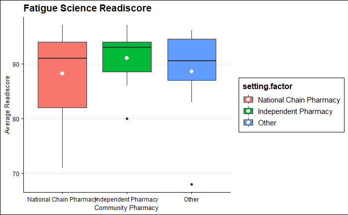

```r
ggplot(data, aes(x=setting.factor, y=readiscore_average, fill=setting.factor))+
    geom_boxplot()+
    theme_clean() +
  stat_summary(fun=mean, geom="point", shape=18, size=3, color="white")+
  ggtitle("Fatigue Science Readiscore")+
  xlab("Community Pharmacy")+
  ylab("Average Readiscore")

ggsave("Average Readiscore.jpeg",
         width = 30, height = 20, units ="cm")
```

Mutate data set to add binary variable of average “high effectiveness”

```r
data.FS = data[,c(2:12,14,20:23,25:27,45)]
data.FS.PFI = data[,c(28:39,45)]

data.FS.log = data.FS%>%
  mutate(high_effect = (readiscore_average >= 90)*1)

data.FS.PFI.log = data.FS.PFI %>%
  mutate(high_effect = (readiscore_average >= 90)*1)

head(data.FS)
```

|  | setting | years_pharmacy | years_pharmacist | prescriptions | full_time_rph | part_time_rph | float_rph | full_time_staff | part_time_staff | float_staff | age | caffeine | gender | marital_status | adults_house | minors_house | days_worked | hours_worked | lunch | readiscore_average |
| --- | --- | --- | --- | --- | --- | --- | --- | --- | --- | --- | --- | --- | --- | --- | --- | --- | --- | --- | --- | --- |
| 1 | 1 | 5.0 | 1.00 | 500 | 1.0 | 1 | 0 | 5 | 0 | 1 | 30 | 4.0 | 2 | 1 | 2 | 0 | 11 | 8.0 | 1 | 82 |
| 2 | 5 | 0.5 | 0.50 | 150 | 1.5 | 0 | 0 | 2 | 0 | 0 | 29 | 2.0 | 2 | 1 | 1 | 0 | 10 | 8.0 | 1 | 96 |
| 3 | 1 | 5.0 | 5.00 | 550 | 1.0 | 0 | 0 | 1 | 0 | 0 | 56 | 4.5 | 1 | 2 | 2 | 3 | 9 | 10.0 | 1 | 71 |
| 4 | 1 | 5.5 | 0.34 | 380 | 1.0 | 0 | 0 | 3 | 1 | 0 | 26 | 0.0 | 2 | 1 | 1 | 0 | 10 | 12.5 | 1 | 91 |
| 5 | 1 | 31.0 | 31.00 | 1200 | 5.0 | 0 | 0 | 6 | 4 | 0 | 54 | 2.0 | 2 | 2 | 2 | 0 | 9 | 10.0 | 0 | 94 |
| 6 | 4 | 1.0 | 1.00 | 17 | 1.0 | 0 | 0 | 0 | 0 | 0 | 27 | 1.0 | 2 | 2 | 2 | 0 | 10 | 8.0 | 1 | 93 |

```r
head(data.FS.PFI)
```

|  | energy | tired | pain | thinking | forget | spent_longer | keep_up | impatient | performing | short_cuts | above_beyond | fatigue_general | readiscore_average |
| --- | --- | --- | --- | --- | --- | --- | --- | --- | --- | --- | --- | --- | --- |
| 1 | 2 | 2 | 2 | 2 | 1 | 2 | 4 | 1 | 3 | 2 | 3 | 3 | 82 |
| 2 | 4 | 5 | 2 | 2 | 2 | 3 | 3 | 5 | 3 | 2 | 4 | 4 | 96 |
| 3 | 5 | 5 | 2 | 3 | 3 | 4 | 5 | 5 | 4 | 4 | 5 | 5 | 71 |
| 4 | 3 | 4 | 4 | 2 | 4 | 2 | 4 | 1 | 3 | 2 | 3 | 1 | 91 |
| 5 | 5 | 5 | 4 | 4 | 1 | 4 | 5 | 5 | 4 | 4 | 5 | 5 | 94 |
| 6 | 1 | 2 | 1 | 1 | 1 | 1 | 1 | 1 | 1 | 1 | 1 | 1 | 93 |

```r
head(data.FS.PFI.log)
```

|  | energy | tired | pain | thinking | forget | spent_longer | keep_up | impatient | performing | short_cuts | above_beyond | fatigue_general | readiscore_average | high_effect |
| --- | --- | --- | --- | --- | --- | --- | --- | --- | --- | --- | --- | --- | --- | --- |
| 1 | 2 | 2 | 2 | 2 | 1 | 2 | 4 | 1 | 3 | 2 | 3 | 3 | 82 | 0 |
| 2 | 4 | 5 | 2 | 2 | 2 | 3 | 3 | 5 | 3 | 2 | 4 | 4 | 96 | 1 |
| 3 | 5 | 5 | 2 | 3 | 3 | 4 | 5 | 5 | 4 | 4 | 5 | 5 | 71 | 0 |
| 4 | 3 | 4 | 4 | 2 | 4 | 2 | 4 | 1 | 3 | 2 | 3 | 1 | 91 | 1 |
| 5 | 5 | 5 | 4 | 4 | 1 | 4 | 5 | 5 | 4 | 4 | 5 | 5 | 94 | 1 |
| 6 | 1 | 2 | 1 | 1 | 1 | 1 | 1 | 1 | 1 | 1 | 1 | 1 | 93 | 1 |

## Work System Model

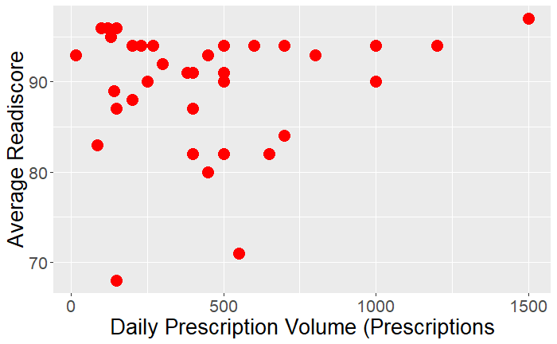

```r
data.FS %>%
  ggplot(aes(x=prescriptions, y=readiscore_average))+
  geom_point(colour = "red", size=5)+
  xlab("Daily Prescription Volume (Prescriptions")+
  ylab("Average Readiscore") +
  theme(text = element_text(size = 20))

  ggsave("Prescriptions on ReadiScore.jpeg",
         width = 30, height = 20, units ="cm")
```

```r
NA
```

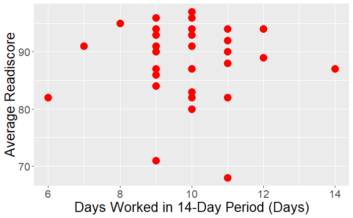

```r
data.FS %>%
  ggplot(aes(x=days_worked, y=readiscore_average))+
  geom_point(colour = "red", size=5)+
  xlab("Days Worked in 14-Day Period (Days)")+
  ylab("Average Readiscore")+
  theme(text = element_text(size = 20))

ggsave("Days Worked on Readiscore.jpeg",
         width = 30, height = 20, units ="cm")
```

## Personal Model

```r
data.FS %>%
  ggplot(aes(x=age, y=readiscore_average))+
   geom_point(colour = "red", size=5)+
  xlab("Age (Years)")+
  ylab("Average Readiscore")+
  theme(text = element_text(size = 20))

ggsave("Age on ReadiScore.jpeg",
         width = 30, height = 20, units ="cm")
```

```r
data.FS %>%
  ggplot(aes(x=minors_house, y=readiscore_average))+
  geom_point(colour = "red", size=5)+
  xlab("Individuals Under 18 Years Old in House (Minors)")+
  ylab("Average Readiscore")+
  theme(text = element_text(size = 20))

ggsave("Minors on ReadiScore.jpeg",
         width = 30, height = 20, units ="cm")
```

```r
data.FS %>%
  ggplot(aes(x=caffeine, y=readiscore_average))+
    geom_point(colour = "red", size=5)+
  xlab("Daily Caffeine Intake (Servings)")+
  ylab("Average Readiscore")+
  theme(text = element_text(size = 20))

ggsave("Caffeine on ReadiScore.jpeg",
         width = 30, height = 20, units ="cm")
```

```r
data.FS %>%
  ggplot(aes(x=years_pharmacist, y=readiscore_average))+
    geom_point(colour = "red", size=5)+
  xlab("Years Working in Pharmacy as Pharmacist (Years)")+
  ylab("Average Readiscore")+
  theme(text = element_text(size = 20))

ggsave("Years Pharmacist on ReadiScore.jpeg",
         width = 30, height = 20, units ="cm")
```

```r
data.FS %>%
  ggplot(aes(x=adults_house, y=readiscore_average))+
    geom_point(colour = "red", size=5)+
  xlab("Individuals Over 18 Years Old In the House (Adults)")+
  ylab("Average Readiscore")+
  theme(text = element_text(size = 20))

ggsave("Adults on ReadiScore.jpeg",
         width = 30, height = 20, units ="cm")
```

# OLSRR Package

```r
data.FS = data[,c(2:12,14,20:23,25:27,45)] %>%
  mutate(chain = (setting ==1)*1) %>%
  mutate(independent =(setting==4)*1) %>%
  mutate(other = (setting==5)*1)

data.FS1 <- subset(data.FS, select = -c(setting)) %>%
  slice(-c(40))



model.readi1 <- lm(data=data.FS1, readiscore_average ~.)

Aim1.2<- ols_step_both_p(model.readi1, penter=0.1, details=TRUE)
plot(Aim1.2)


Aim1.2 <- lm(data=data.FS1, readiscore_average ~
               minors_house +
               adults_house )
```

```r
ols_plot_resid_qq(Aim1.2)
```

```r
ols_test_normality(Aim1.2)
```

```r
ols_plot_resid_fit(Aim1.2)
```

```r
ols_plot_resid_hist(Aim1.2)
```

```r
ols_plot_cooksd_bar(Aim1.2)
```

```r
ols_plot_resid_stud(Aim1.2)
```

```r
ols_test_breusch_pagan(Aim1.2, rhs = TRUE, multiple = TRUE, p.adj = 'bonferroni')
```

```r
ols_test_score(Aim1.2)
```

```r
ols_vif_tol(Aim1.2)
```

```r
ols_plot_obs_fit(Aim1.2)
```

```r
data.FS.log %>%
  mutate(chain = (setting ==1)*1) %>%
  mutate(independent =(setting==4)*1) %>%
  mutate(other = (setting==5)*1)

data.FS.log1 <- subset(data.FS.log, select = -c(readiscore_average)) %>%
  slice(-c(40))

data.FS.log2 <- subset(data.FS.log1, select = -c(setting))


model.readi2 <- glm(data=data.FS.log2, high_effect ~ ., family = binomial)
summary(model.readi2)
```